## JobCraftingWS1920

**1. Teammitglieder:** Caroline Kreiß, Jennifer Schnier, Isabel Grevenstein, Maike Holle, Jessica Schmitz

**2. Unser Fokus:**

- Wir wollen das Job Crafting von Personen in Abhängigkeit von der Qualität der Kommunikation innerhalb eines Unternehmens untersuchen.
- Außerdem prüfen wir, welche Unterschiede es dabei hinsichtlich des regulatorischen Fokus gibt, das heißt wie sich dabei das Job Crafting zwischen Personen mit einem Prevention Focus und mit einem Promotion Focus unterscheidet.
- Dabei arbeiten wir mit zwei Szenarien, in denen beschrieben wird, dass ein digitaler Instant-Messaging-Dienst zur Kommunikation (z. B. Slack) in einem Unternehmen eingeführt wird. In einem Szenario beschreiben wir, dass die Kommunikation zur Einführung des Programms qualitativ hochwertig war. In dem anderen Szenario schreiben wir, dass diese Kommunikation qualitativ minderwertiger war.
- Wir wollen herausfinden, inwieweit sich das Job Crafting der Befragten zwischen diesen beiden Szenarien und in Bezug auf ihren regulatorischen Fokus unterscheidet.

**3. Fragestellung:** Wie unterscheidet sich das Job Crafting zwischen gewinn- und sicherheitsorientierten Personen in Abhängigkeit von der Qualität der Kommunikation von organisatorischen Veränderungen?

**4. Faktorenraum**

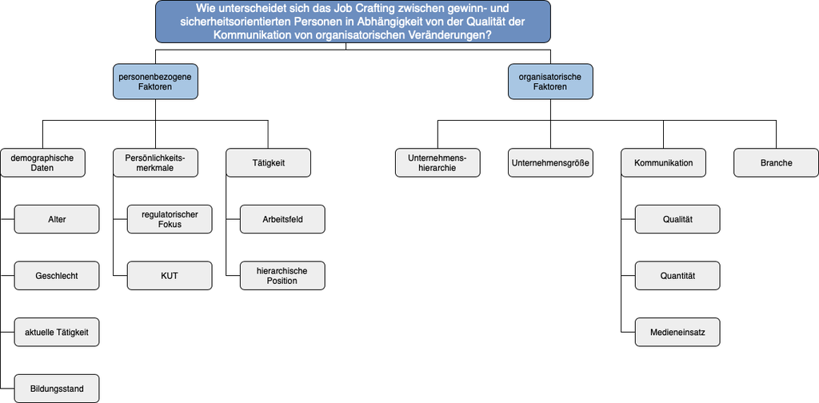

Faktorenraum

**5. Was genau wir in unserem Fragebogen messen wollen …**

- demografische Daten (Alter, Geschlecht, aktuelle Tätigkeit, höchster Bildungsabschluss)
- regulatorischer Fokus (Promotion Focus, Prevention Focus)
- Job Crafting (bei qualitativ hochwertiger vs. bei qualitativ minderwertiger Unternehmenskommunikation)

**6. Unsere Skalen**

Regulatorischer Fokus (auf einer Skala von 1 (stimme gar nicht zu) bis 6 (stimme völlig zu)) (vgl. Neubert et al. 2008):

- Ich nutze Chancen bei der Arbeit, um das Beste für meine Weiterentwicklung zu erreichen.
- Ich neige dazu, Risiken bei der Arbeit einzugehen, um Erfolg zu haben.
- Wenn mein Job mir keine Weiterentwicklungsmöglichkeiten bieten würde, würde ich mich nach einem neuen Job umsehen.
- Die Chance auf Weiterentwicklung ist ein wichtiger Faktor für mich bei der Arbeitsplatzsuche.
- Ich konzentriere mich darauf, meine Arbeitsaufgaben korrekt abzuschließen, um meinen Arbeitsplatz zu sichern.
- Bei der Arbeit konzentriere ich mich darauf, meine Aufgabenbereiche vollständig auszufüllen.
- Meine Verpflichtungen auf der Arbeit zu erfüllen ist sehr wichtig für mich.

-> Diese Skala wird auch von der Gruppe Transformation/Leadership verwendet.

Job Crafting (auf einer Skala von 1 (stimme gar nicht zu) bis 6 (stimme völlig zu)) Als Basis für die Messung des Job Craftings haben wir die Skala aus dem uns vorliegenden Paper verwendet (vgl. Petrou et al. 2012). Diese haben wir auf Deutsch übersetzt und inhaltlich an unsere Szenarien angepasst: Die Art, wie diese Änderung in meinem Unternehmen an mich kommuniziert wird, bringt mich dazu …

- … Kollegen um Rat zu dem neu eingeführten Programm zu fragen. (Grad der Suche nach Hilfestellungen)
- … meinen Vorgesetzten um Rat zu dem neu eingeführten Programm zu fragen. (Grad der Suche nach Hilfestellungen)
- … dass ich versuche, Neues zu dem eingeführten Programm zu lernen. (Grad der Suche nach Hilfestellungen)
- … dass ich noch mehr Funktionen des Programms kennenlernen möchte, sobald ich die Grundlagen verstanden habe. (Grad der Suche nach Herausforderungen)
- … dass ich mich aktiv daran beteiligen möchte, das neue Programm im Unternehmen zu etablieren. (Grad der Suche nach Herausforderungen)
- … dass ich anderen Leuten dabei helfe, das Programm zu verstehen. (Grad der Suche nach Herausforderungen)
- … dass ich versuche, die Einarbeitung in das Programm für mich so zu gestalten, dass sie mental wenig anspruchsvoll ist. (Grad der Reduktion von Anforderungen)
- … dass ich versuche, die Einarbeitung in das Programm für mich so zu gestalten, dass sie emotional wenig anspruchsvoll ist. (Grad der Reduktion von Anforderungen)
- … dass ich versuche, die Nutzung des Programms für mich so simpel wie möglich zu halten. (Grad der Reduktion von Anforderungen)

**7. Hypothesen**

**Unterschiedshypothesen**

1. Hypothese: Das Job Crafting bei qualitativ hochwertiger Kommunikation von organisatorischen Veränderungen in einem Unternehmen ist abhängig von dem Prevention Focus und dem Promotion Focus.  
   **H0**: Das Job Crafting bei qualitativ hochwertiger Kommunikation von organisatorischen Verändeurngen in einem Unternehmen ist nicht abhängig vn dem Prevention Focus und dem Promotion Focus.  
   **H1**: Das Job Crafting bei qualitativ hochwertiger Kommunikation von organisatorischen Veränderungen in einem Unternehmen ist abhängig von dem Prevention Focus und dem Promotion Focus.  
   **Testverfahren**: zweifaktorielle ANOVA  
   **UV**: Prevention Focus, Promotion Focus  
   **AV**: Grad des Job Craftings bei hochwertiger Kommunikation
2. Hypothese: Das Job Crafting bei qualitativ minderwertiger Kommunikation von organisatorischen Veränderungen in einem Unternehmen ist abhängig von dem Prevention Focus und dem Promotion Focus.  
   **H0**: Das Job Crafting bei qualitativ minderwertiger Kommunikation von organisatorischen Veränderungen in einem Unternehmen ist nicht abhängig von dem Prevention Focus und dem Promotion Focus.  
   **H1**: Das Job Crafting bei qualitativ minderwertiger Kommunikation von organisatorischen Veränderungen in einem Unternehmen ist abhängig von dem Prevention Focus und dem Promotion Focus.  
   **Testverfahren**: zweifaktorielle ANOVA  
   **UV**: Prevention Focus, Promotion Focus  
   **AV**: Grad des Job Craftings bei minderwertiger Kommunikation
3. Hypothese: Personen mit einem Prevention Focus haben ein höheres Job Crafting bei qualitativ minderwertiger Kommunikation von organisatorischen Veränderungen als Personen ohne Prevention Focus.  
   **H0**: Personen mit und ohne Prevention Focus gleichen sich hinsichtlich des Job Craftings bei qualitativ minderwertiger Kommunikation von organisatorischen Veränderungen.  
   **H1**: Personen mit und ohne Prevention Focus unterscheiden sich hinsichtlich des Job Crafting bei qualitativ minderwertiger Kommunikation von organisatorischen Veränderungen.  
   **Testverfahren**: unverbundener t-Test  
   **UV**: Prevention Focus (Prevention Focus vs. kein Prevention Focus)  
   **AV**: Grad des Job Craftings bei minderwertiger Kommunikation
4. Hypothese: Personen mit einem Promotion Focus haben ein höheres Job Crafting bei qualitativ hochwertiger Kommunikation von organisatorischen Veränderungen als Personen ohne Promotion Focus.  
   **H0**: Personen mit und ohne Promotion Focus gleichen sich hinsichtlich des Job Craftings bei qualitativ hochwertiger Kommunikation von organisatorischen Veränderungen.  
   **H1**: Personen mit und ohne Promotion Focus unterscheiden sich hinsichtlich des Job Craftings bei qualitativ hochwertiger Kommunikation von organisatorischen Veränderungen.  
   **Testverfahren**: unverbundener t-Test  
   **UV**: Promotion Focus (Promotion Focus vs. kein Promotion Focus)  
   **AV**: Grad des Job Craftings bei hochwertiger Kommunikation
5. Hypothese: Es besteht ein Unterschied im Job Crafting zwischen Personen mit unterschiedlichen Tätigkeitstypen.  
   **H0**: Personen mit unterschiedlichen Tätigkeitstypen gleichen sich in ihrem Job Crafting. **H1**: Es besteht ein Unterschied im Job Crafting zwischen Personen mit unterschiedlichen Tätigkeitstypen.  
   **Testverfahren**: einfaktorielle ANOVA  
   **UV**: Tätigkeit (Schüler, Student, Auszubildender, Angestellter, Selbstständiger, Rentner, Arbeitssuchender)  
   **AV**: Grad des Job Craftings

**Zusammenhangshypothesen**

6. Hypothese: Je höher der Prevention Focus, desto höher ist das Job Crafting bei qualitativ minderwertiger Kommunikation von organisatorischen Veränderungen.  
   **H0**: Es gibt keinen Zusammenhang zwischen Prevention Focus und Job Crafting bei qualitativ minderwertiger Kommunikation von organisatorischen Veränderungen.  
   **H1**: Es gibt einen Zusammenhang zwischen Prevention Focus und Job Crafting bei qualitativ minderwertiger Kommunikation von organisatorischen Veränderungen.  
   **Testverfahren**: Korrelation (Pearson)
7. Hypothese: Je höher der Promotion Focus, desto höher ist das Job Crafting bei qualitativ hochwertiger Kommunikation von organisatorischen Veränderungen.  
   **H0**: Es gibt keinen Zusammenhang zwischen Promotion Focus und Job Crafting bei qualitativ hochwertiger Kommunikation von organisatorischen Veränderungen.  
   **H1**: Es gibt einen Zusammenhang zwischen Promotion Focus und Job Crafting bei qualitativ hochwertiger Kommunikation von organisatorischen Veränderungen.  
   **Testverfahren**: Korrelation (Pearson)
8. Hypothese: Je höher der Prevention Focus, desto eher sucht man nach Hilfestellungen bei qualitativ minderwertiger Kommunikation von organisatorischen Veränderungen.  
   **H0**: Es gibt keinen Zusammenhang zwischen Prevention Focus und der Suche nach Hilfestellungen bei qualitativ minderwertiger Kommunikation von organisatorischen Veränderungen.  
   **H1**: Es gibt einen Zusammenhang zwischen Prevention Focus und der Suche nach Hilfestellungen bei qualitativ minderwertiger Kommunikation von organisatorischen Veränderungen.  
   **Testverfahren**: Korrelation (Pearson)
9. Hypothese: Job Crafting bei qualitativ minderwertiger Kommunikation von organisatorischen Veränderungen ist abhängig von dem Prevention Focus und dem Promotion Focus.  
   **H0**: Es besteht keine Abhängigkeit des Job Craftings bei qualitativ minderwertiger Kommunikation von organisatorischen Veränderungen von dem Prevention Focus und dem Promotion Focus.  
   **H1**: Es besteht eine Abhängigkeit des Job Craftings bei qualitativ minderwertiger Kommunikation von organisatorischen Veränderungen von dem Prevention Focus und dem Promotion Focus.  
   **Testverfahren**: lineare Regression
10. Hypothese: Job Crafting bei qualitativ hochwertiger Kommunikation von organisatorischen Veränderungen ist abhängig von dem Prevention Focus und dem Promotion Focus.  
    **H0**: Es besteht keine Abhängigkeit des Job Craftings bei qualitativ hochwertiger Kommunikation von organisatorischen Veränderungen von dem Prevention Focus und dem Promotion Focus.  
    **H1**: Es besteht eine Abhängigkeit des Job Craftings bei qualitativ hochwertiger Kommunikation von organisatorischen Veränderungen von dem Prevention Focus und dem Promotion Focus.  
    **Testverfahren**: lineare Regression